# 4DN DamID - Ki67 project - Osmotic shock

Tom van Schaik

2022-07-01

### Project

Mapping of Ki67 interactions with the genome and comparison with lamina interactions.

### Introduction

Various analyses of RPE cells following osmotic shock.

### Method

NA

### Set-up

Set the parameters and list the data.

```r
# Load dependencies - without warnings / messages
library(tidyverse)
library(GenomicRanges)
library(rtracklayer)
library(ggplot2)
library(RColorBrewer)
library(GGally)
library(corrr)
library(caTools)
library(ggbeeswarm)

# Prepare output
output_dir <- "ts220503_5_osmotic_shock"
dir.create(output_dir, showWarnings = FALSE)


# Load input
chromosomes <- c(paste0("chr", 1:22), "chrX")


input_dir <- "ts220503_1_data_gathering"

bin_size <- readRDS(file.path(input_dir, "bin_size.rds"))
centromeres <- readRDS(file.path(input_dir, "centromeres.rds"))

colors_set1 <- readRDS(file.path(input_dir, "colors_set1.rds"))
colors_set2 <- readRDS(file.path(input_dir, "colors_set2.rds"))
colors_set3 <- readRDS(file.path(input_dir, "colors_set3.rds"))

tib_padamid_replicates <- readRDS(file.path(input_dir,
                                            "tib_padamid_replicates.rds"))
tib_padamid_combined <- readRDS(file.path(input_dir,
                                          "tib_padamid_combined.rds"))

gr_padamid_replicates <- readRDS(file.path(input_dir,
                                           "gr_padamid_replicates.rds"))
gr_padamid_combined <- readRDS(file.path(input_dir,
                                         "gr_padamid_combined.rds"))

tib_hmm_replicates <- readRDS(file.path(input_dir, "tib_hmm_replicates.rds"))
tib_hmm_combined <- readRDS(file.path(input_dir, "tib_hmm_combined.rds"))

padamid_metadata_replicates <- readRDS(file.path(input_dir,
                                                 "padamid_metadata_replicates.rds"))
padamid_metadata_combined <- readRDS(file.path(input_dir,
                                               "padamid_metadata_combined.rds"))



# Prepare seqnames
chrom_sizes <- tibble(seqnames = seqlevels(gr_padamid_combined),
                      length = seqlengths(gr_padamid_combined)) %>%
  arrange(-length)


# Scale pA-DamID scores?
tib_padamid_combined <- tib_padamid_combined %>%
  mutate_at(4:ncol(.), function(x) scale(x)[, 1])
```

```r
library(knitr)
opts_chunk$set(fig.width = 10, fig.height = 4, cache = T,
               dev=c('png', 'pdf'), fig.path = file.path(output_dir, "figures/"))
pdf.options(useDingbats = FALSE)
```

```r
# From Fede:
# ggpairs custom functions
corColor <- function(data, mapping, color = I("black"), sizeRange = c(1, 3), ...) {

  x   <- eval_data_col(data, mapping$x)
  y   <- eval_data_col(data, mapping$y)
  r   <- cor(x, y)
  rt  <- format(r, digits = 3)
  tt  <- as.character(rt)
  cex <- max(sizeRange)

  # helper function to calculate a useable size
  percent_of_range <- function(percent, range) {
    percent * diff(range) + min(range, na.rm = TRUE)
  }

  # plot correlation coefficient
  p <- ggally_text(label = tt, mapping = aes(), xP = 0.5, yP = 0.5,
                   # size = I(percent_of_range(cex * abs(r), sizeRange)),
                   size = 6,
                   color = color, ...) +
    theme(panel.grid.minor=element_blank(),
          panel.grid.major=element_blank())

  corColors <- RColorBrewer::brewer.pal(n = 7, name = "RdYlBu")[2:6]

  if (r <= boundaries[1]) {
    corCol <- corColors[1]
  } else if (r <= boundaries[2]) {
    corCol <- corColors[2]
  } else if (r < boundaries[3]) {
    corCol <- corColors[3]
  } else if (r < boundaries[4]) {
    corCol <- corColors[4]
  } else {
    corCol <- corColors[5]
  }

  p <- p +
    theme(panel.background = element_rect(fill = corCol))

  return(p)
}

customScatter <- function (data, mapping)
{
    p <- ggplot(data = data, mapping) +
      geom_bin2d(bins = 100) +
      geom_smooth(method = "lm", se = T, col = "red") +
      scale_fill_gradient(low = "lightgrey", high = "black", name = "Count") +
      theme_bw()

    p
}

PlotScatter <- function(tib, n1, n2, color_by = NULL, identity = F,
                        xlimits = NULL, facet_seqnames = F,
                        smooth_line = F, smooth_seqnames = F) {
  # Get tibble
  tib <- tib %>%
    dplyr::select(seqnames, matches(n1), matches(n2)) %>%
    rename_all(~ c("seqnames", "n1", "n2")) %>%
    mutate(seqnames = factor(seqnames,
                             levels = seqlevels(gr_padamid_combined)))

  # Prepare color
  if (! is.null(color_by)) {
    tib <- tib %>%
      add_column(color = color_by) %>%
      drop_na()
    alpha = 1
    limits_color <- quantile(tib$color, c(0.001, 0.999), na.rm = T)
    tib$color[tib$color < limits_color[1]] <- limits_color[1]
    tib$color[tib$color > limits_color[2]] <- limits_color[2]
  } else {
    tib <- tib %>% drop_na()
    tib$color = "1"
    alpha = 0.02
  }

  # Plot
  if (is.null(xlimits)) {
    xlimits <- quantile(tib$n1, c(0.001, 0.999), na.rm = T) * 1.4
  }
  ylimits <- quantile(tib$n2, c(0.001, 0.999), na.rm = T) * 1.4

  plt <- tib %>%
    arrange(sample(1:nrow(.), size = nrow(.), replace = F)) %>%
    ggplot(aes(x = n1, y = n2, color = color)) +
    geom_point(size = 0.5, alpha = alpha) +
    geom_hline(yintercept = 0, col = "black", linetype = "dashed") +
    geom_vline(xintercept = 0, col = "black", linetype = "dashed") +
    xlab(n1) +
    ylab(n2) +
    ggtitle(paste0("Spearman: ",
                   round(cor(tib$n1, tib$n2, use = "complete.obs",
                             method = "spearman"), 2))) +
    coord_cartesian(xlim = xlimits, ylim = ylimits) +
    theme_bw() +
    theme(aspect.ratio = 1)

  # Prepare color
  if (! is.null(color_by)) {
    plt <- plt +
      scale_color_gradient2(low = "blue", mid = "grey", high = "red",
                            midpoint = 0)
  } else {
    plt <- plt +
      scale_color_manual(values = "black", guide = F)
  }
  if (identity) plt <- plt + geom_abline(slope = 1, intercept = 0, col = "red", linetype = "dashed")

  # Facets / smooth
  if (facet_seqnames) plt <- plt + facet_wrap(~ seqnames)
  if (smooth_line) plt <- plt + geom_smooth(method = "loess", span = 0.7, se = F, col = "black")
  if (smooth_seqnames) plt <- plt + geom_smooth(aes(group = seqnames),
                                                alpha = 0.2, col = "black",
                                                method = "loess", span = 0.7, se = F)

  plot(plt)

}

PlotScatterBinned <- function(tib, n1, n2, color_by = NULL, identity = F,
                              n_min = 10, ylimits_col = c(-2.4, 2.4),
                              count_range = c(0, 400)) {
  # Get tibble
  tib_process <- tib %>%
    dplyr::select(seqnames, all_of(n1), all_of(n2)) %>%
    rename_all(~ c("seqnames", "n1", "n2"))

  if (! is.null(color_by)) {
    tib_process <- tib_process %>%
      add_column(color = color_by)
  }

  tib_process <- tib_process %>%
    drop_na()

  # Change color range
  if (! is.null(color_by)) {
    limits_color <- quantile(tib_process$color, c(0.001, 0.999), na.rm = T)
    tib_process$color[tib_process$color < limits_color[1]] <- limits_color[1]
    tib_process$color[tib_process$color > limits_color[2]] <- limits_color[2]
  }

  # Metrics
  n1_min = min(tib_process$n1) - 0.001
  n1_max = max(tib_process$n1) + 0.001
  n1_binsize <- (n1_max - n1_min) / 49

  n2_min = min(tib_process$n2) - 0.001
  n2_max = max(tib_process$n2) + 0.001
  n2_binsize <- (n2_max - n2_min) / 49

  tib_summary <- tib_process %>%
    mutate(n1_cut = cut(n1,
                        seq(n1_min, n1_max, length.out = 50)),
           n2_cut = cut(n2,
                        seq(n2_min, n2_max, length.out = 50))) %>%
    mutate(n1_bin = as.numeric(as.factor(n1_cut)),
           n2_bin = as.numeric(as.factor(n2_cut))) %>%
    mutate(n1_bin = n1_min - n1_binsize/2 + n1_bin * n1_binsize,
           n2_bin = n2_min - n2_binsize/2 + n2_bin * n2_binsize) %>%
    group_by(n1_bin, n2_bin)

  # Plot
  if (! is.null(color_by)) {
    tib_summary <- tib_summary %>%
    dplyr::summarise(n = n(),
                     mark = mean(color)) %>%
    ungroup() %>%
    filter(n >= n_min)

    plt <- tib_summary %>%
      ggplot(aes(x = n1_bin, y = n2_bin)) +
      geom_tile(aes(fill = mark)) +
      scale_fill_gradient2(low = "blue", mid = "grey", high = "red",
                           midpoint = 0, limits = ylimits_col,
                           na.value = "green")
  } else {
    tib_summary <- tib_summary %>%
    dplyr::summarise(n = n()) %>%
    ungroup() %>%
    filter(n >= n_min)

    plt <- tib_summary %>%
      ggplot(aes(x = n1_bin, y = n2_bin)) +
      geom_tile(aes(fill = n)) +
      scale_fill_gradient(low = "lightgrey", high = "black", name = "Count",
                          limits = count_range, na.value = "green")
  }

  plt <- plt +
    geom_hline(yintercept = 0, linetype = "dashed", col = "black") +
    geom_vline(xintercept = 0, linetype = "dashed", col = "black") +
    xlab(n1) +
    ylab(n2) +
    ggtitle(paste0("Pearson: ",
                   round(cor(tib_process$n1, tib_process$n2, use = "complete.obs",
                             method = "pearson"), 2))) +
    theme_bw() +
    theme(aspect.ratio = 1)

  if (identity) plt <- plt + geom_abline(slope = 1, intercept = 0,
                                         col = "black", linetype = "dashed")

  plot(plt)

}

quantiles <- function(x) {
  # Use quantiles as boxplot boundaries
  r <- quantile(x, probs = c(0.05, 0.25, 0.5, 0.75, 0.95))
  names(r) <- c("ymin", "lower", "middle", "upper", "ymax")
  r
}
```

### 1. Comparison with cell cycle interactions

Is a simple scatter plot convincing?

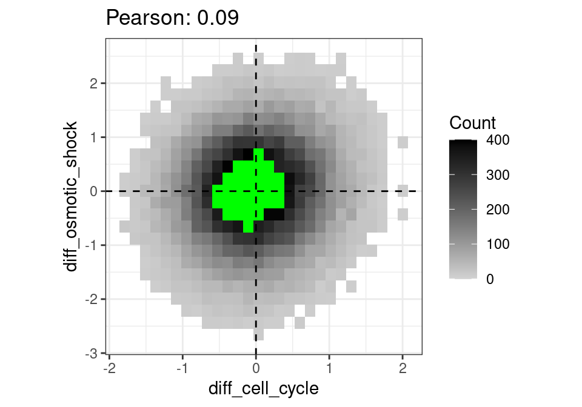

```r
# Are the differences the same?
tib <- tib_padamid_combined %>%
  mutate(diff_cell_cycle = RPE_wt_Ki67 - RPE_3h_Ki67,
         diff_osmotic_shock = RPE_Osm_180m_Ki67 - RPE_Osm_30m_Ki67) %>%
  filter(seqnames != "chrY")

PlotScatterBinned(tib,
                  n1 = "diff_cell_cycle",
                  n2 = "diff_osmotic_shock")
```

Simple scatter plots do not work - too noisy data I’m afraid.

How about chromosomal differences?

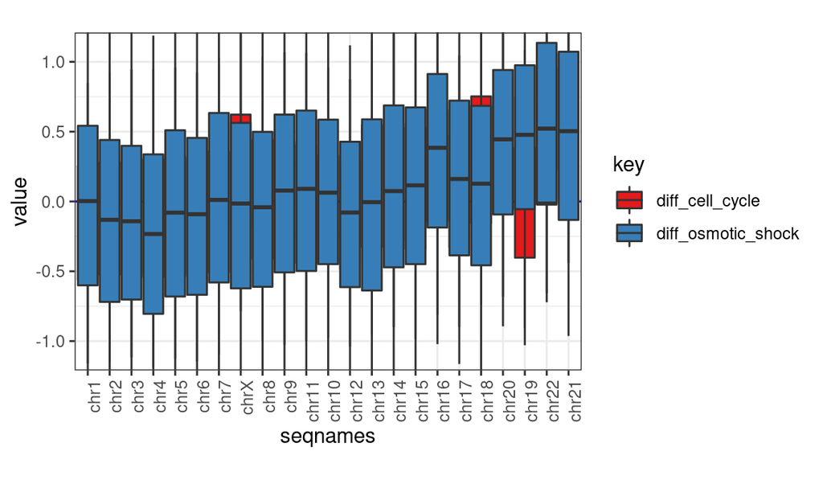

```r
# Boxplots
tib %>%
  gather(key, value, contains("diff")) %>%
  mutate(seqnames = factor(seqnames, chrom_sizes$seqnames)) %>%
  ggplot(aes(x = seqnames, y = value, fill = key)) +
  geom_hline(yintercept = 0, linetype = "dashed", col = "blue") +
  #geom_boxplot(outlier.shape = NA) +
  stat_summary(fun.data = quantiles, geom = "boxplot") +
  coord_cartesian(ylim = c(-1.1, 1.1)) +
  scale_fill_brewer(palette = "Set1") +
  theme_bw() +
  theme(aspect.ratio = 2/3,
        axis.text.x = element_text(angle = 90, hjust = 1))
```

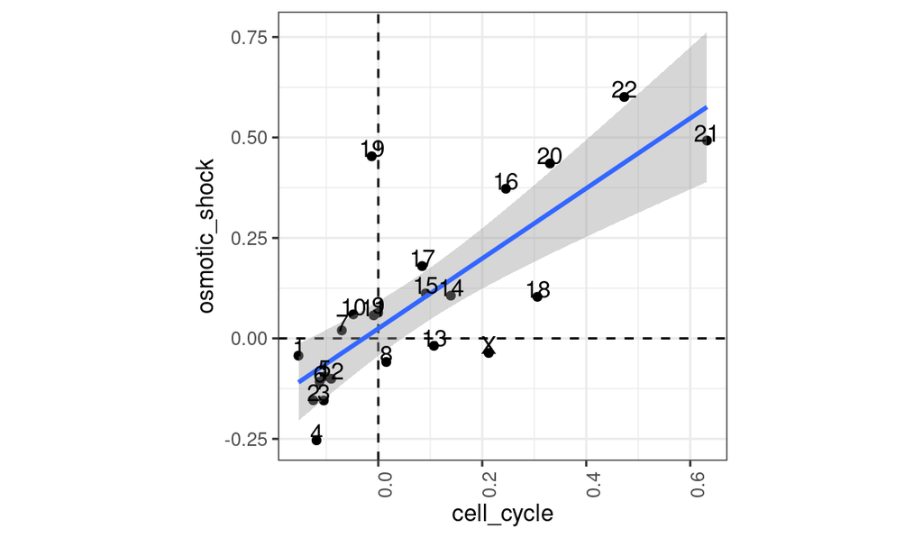

```r
# Scatter plot
tib %>%
  mutate(seqnames = factor(seqnames, chrom_sizes$seqnames)) %>%
  group_by(seqnames) %>%
  dplyr::summarise(cell_cycle = mean(diff_cell_cycle, na.rm = T),
                   osmotic_shock = mean(diff_osmotic_shock, na.rm = T)) %>%
  ungroup() %>%
  ggplot(aes(x = cell_cycle, y = osmotic_shock)) +
  geom_hline(yintercept = 0, linetype = "dashed", col = "black") +
  geom_vline(xintercept = 0, linetype = "dashed", col = "black") +
  geom_point() +
  geom_smooth(method = "lm") +
  geom_text(aes(label = str_remove(seqnames, "chr"), y = osmotic_shock + 0.02)) +
  theme_bw() +
  theme(aspect.ratio = 1,
        axis.text.x = element_text(angle = 90, hjust = 1))
```

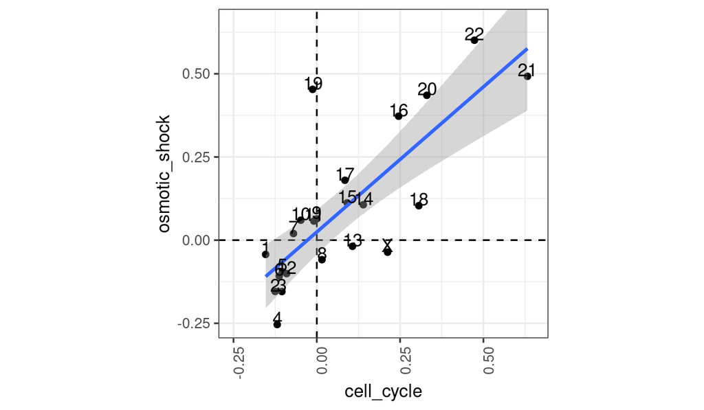

```r
tib %>%
  mutate(seqnames = factor(seqnames, chrom_sizes$seqnames)) %>%
  group_by(seqnames) %>%
  dplyr::summarise(cell_cycle = mean(diff_cell_cycle, na.rm = T),
                   osmotic_shock = mean(diff_osmotic_shock, na.rm = T)) %>%
  ungroup() %>%
  ggplot(aes(x = cell_cycle, y = osmotic_shock)) +
  geom_hline(yintercept = 0, linetype = "dashed", col = "black") +
  geom_vline(xintercept = 0, linetype = "dashed", col = "black") +
  geom_point() +
  geom_smooth(method = "lm") +
  geom_text(aes(label = str_remove(seqnames, "chr"), y = osmotic_shock + 0.02)) +
  coord_cartesian(xlim = c(-0.25, 0.65),
                  ylim = c(-0.25, 0.65)) +
  theme_bw() +
  theme(aspect.ratio = 1,
        axis.text.x = element_text(angle = 90, hjust = 1))
```

### 2. Compare with DamID

In contrast to the title of the document, I will also compare the cell cycle data with the nucleolus data briefly.

```r
# List files
filter_samples_damid <- paste(c("H1", "Hap1", "CENPB", "U2OS", "IMR90"),
                              collapse = "|")

damid_files <- dir("../ts180110_4DN_DataProcessing/results/tracks/normalized/bin-50kb/",
                     recursive = T, full.names = T, pattern = "combined")
damid_files <- grep(filter_samples_damid, damid_files, value = T, invert = T)


# Prepare into metadata
damid_metadata <- tibble(file = damid_files) %>%
  mutate(sample = str_remove(basename(file), "\\..*"),
         sample = str_remove(sample, "-.*")) %>%
  mutate(cell = str_remove(sample, "_.*"),
         target = str_remove(sample, ".*_"),
         replicate = NA,
         combined = T,
         experiment = "wildtype") %>%
  # Add factor levels
  mutate(cell = factor(cell, c("RPE", "HCT116", "K562", "HFF")),
         experiment = factor(experiment, c("wildtype")),
         target = factor(target, c("LMNB1", "4xAP3")),
         replicate = factor(replicate, c("r1", "r2", "r3", "r4", "r5")),
         condition = "wt")

# Load bigwig files - combine into one tibble
tmp <- tib_padamid_combined %>%
  filter(seqnames != "chrY")

for (i in 1:nrow(damid_metadata)) {
  # File name
  f_name <- damid_metadata$sample[i]
  # Read file
  f_tib <- as_tibble(import(damid_metadata$file[i])) %>%
    dplyr::select(-width, -strand) %>%
    dplyr::rename_at(4, ~f_name) %>%
    mutate(seqnames = as.character(seqnames))
  # Add to tibble
  tmp <- full_join(tmp, f_tib)
}
# Rename scores
tib <- tib_damid_combined <- tmp
gr_damid_combined <- as(tib_damid_combined, "GRanges")
```

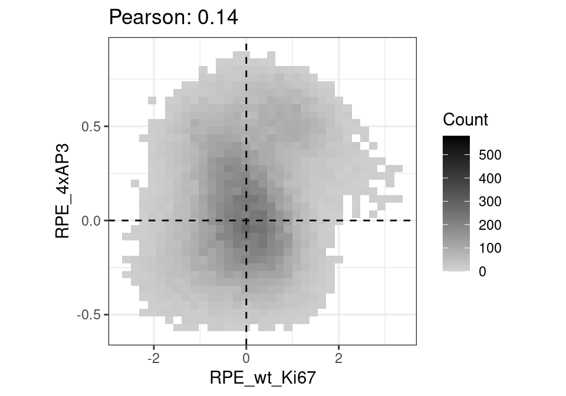

```r
# Scatter plots
PlotScatterBinned(tib,
                  n1 = "RPE_wt_Ki67", n2 = "RPE_4xAP3",
                  count_range = c(0, 580))
```

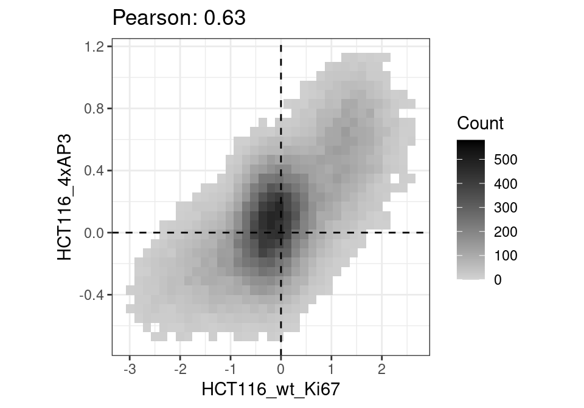

```r
PlotScatterBinned(tib,
                  n1 = "HCT116_wt_Ki67", n2 = "HCT116_4xAP3",
                  count_range = c(0, 580))
```

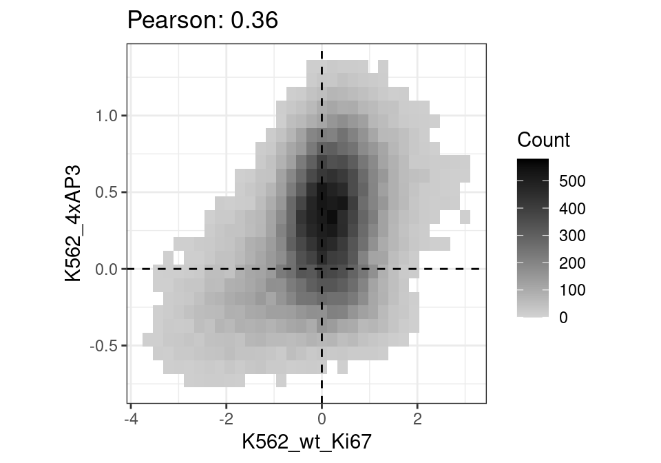

```r
PlotScatterBinned(tib,
                  n1 = "K562_wt_Ki67", n2 = "K562_4xAP3",
                  count_range = c(0, 580))
```

```r
# # Can I show that "intermediate" Ki67 scores have generally high 4xAP3 scores?
# tib %>%
#   dplyr::select(seqnames, RPE_wt_Ki67, RPE_4xAP3) %>%
#   drop_na() %>%
#   rename_at(2:3, ~ c("Ki67", "damid_4xAP3")) %>%
#   arrange(Ki67) %>%
#   mutate(ki67_decile = cut(seq_along(Ki67),
#                            breaks = seq(from = 0, to = nrow(.),
#                                         length.out = 11)),
#          ki67_decile = as.factor(as.numeric(ki67_decile))) %>%
#   ggplot(aes(x = ki67_decile, y = damid_4xAP3)) +
#   geom_boxplot(outlier.shape = NA) +
#   theme_bw() +
#   theme(aspect.ratio = 1)
```

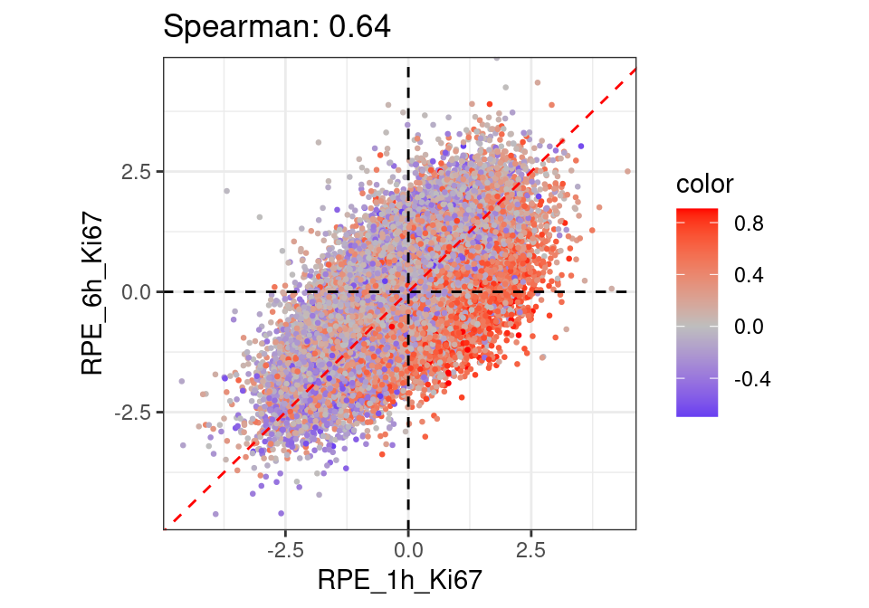

```r
# Scatter plots - colored
PlotScatter(tib,
            n1 = "RPE_1h_Ki67", n2 = "RPE_6h_Ki67",
            color_by = tib$RPE_4xAP3,
            identity = T)
```

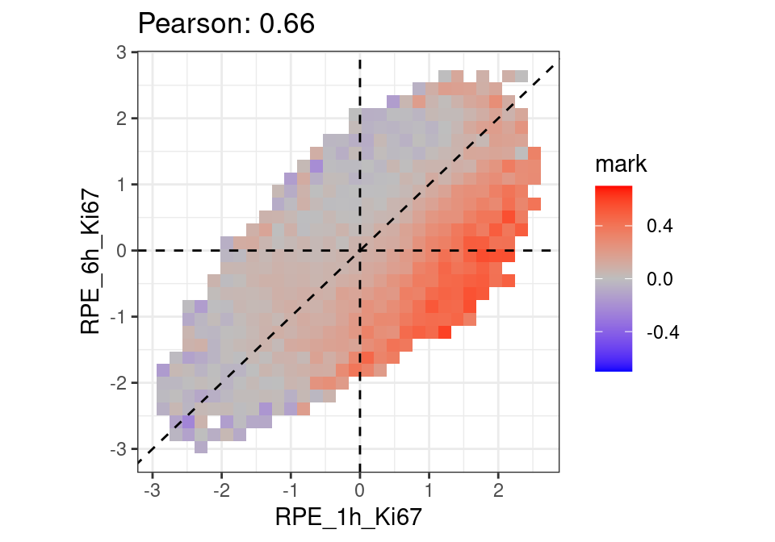

```r
PlotScatterBinned(tib,
                  n1 = "RPE_1h_Ki67", n2 = "RPE_6h_Ki67",
                  color_by = tib$RPE_4xAP3, ylimits_col = c(-0.7, 0.7),
                  identity = T)
```

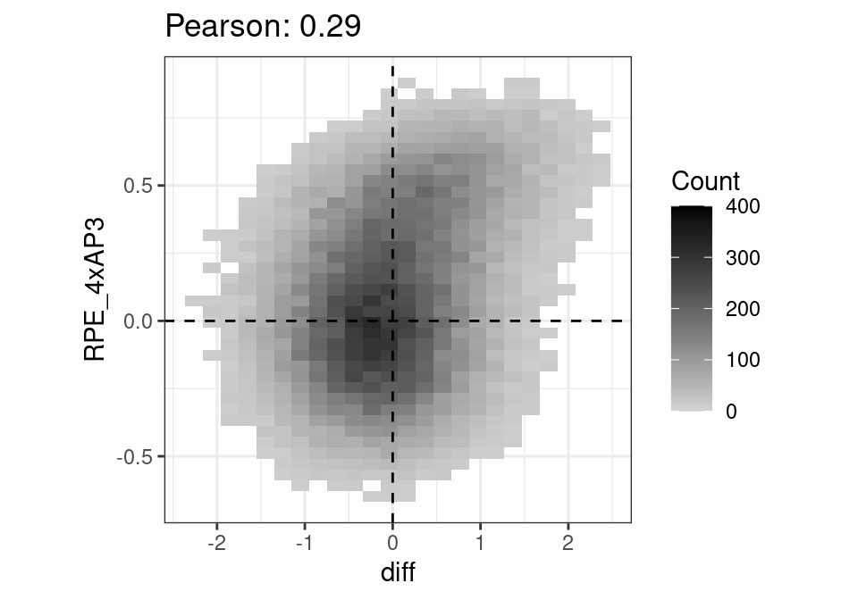

```r
# Difference versus 4xAP3
PlotScatterBinned(tib %>%
                    mutate(diff = RPE_1h_Ki67 - RPE_6h_Ki67),
                  n1 = "diff", n2 = "RPE_4xAP3")
```

```r
# Correlation with time points
tib_cor <- tib %>%
  drop_na() %>%
  gather(key, value, matches("RPE_.*h_Ki67")) %>%
  filter(! key %in% c("RPE_0h_Ki67", "RPE_21h_Ki67")) %>%
  group_by(key, seqnames) %>%
  dplyr::summarise(cor = cor(value, RPE_4xAP3, method = "pearson")) %>%
  mutate(seqnames = factor(seqnames, chrom_sizes$seqnames),
         key = factor(key, padamid_metadata_combined$sample))
```

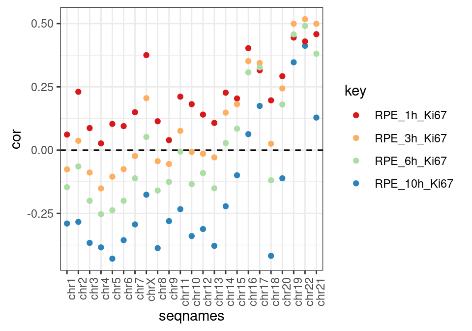

```r
tib_cor %>%
  ggplot(aes(x = seqnames, y = cor, col = key)) +
  geom_point() +
  geom_hline(yintercept = 0, col = "black", linetype = "dashed") +
  scale_color_manual(values = brewer.pal("Spectral", n = 4)) +
  theme_bw() +
  theme(aspect.ratio = 1,
        axis.text.x = element_text(angle = 90, hjust = 1))
```

### 3. Osmotic shock versus cell cycle time points

Request from Bas: show that t=30m is more like early interphase and t=180m is more like late interphase.

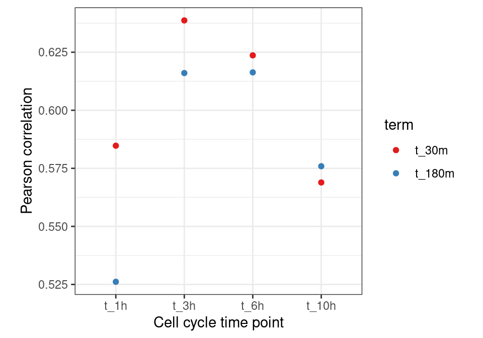

```r
# Pearson correlation of osmotic shock time points with cell cycle time
# points.
tib_padamid_combined %>%
  dplyr::select(matches("RPE_.*h_Ki67"),
                matches("Osm_.*_Ki67"),
                -matches("_0"),
                -matches("_21h_")) %>%
  drop_na() %>%
  # Correlate everything
  correlate(method = "pearson", diagonal = 1, quiet = T) %>%
  # Get osm vs cell cycle correlations
  gather(key, value, -term) %>%
  filter(grepl("Osm", term) &
           ! grepl("Osm", key)) %>%
  mutate(term = str_remove(term, "_Ki67"),
         term = str_replace(term, ".*_", "t_"),
         term = factor(term, levels = unique(term)),
         key = str_remove(key, "_Ki67"),
         key = str_replace(key, ".*_", "t_"),
         key = factor(key, levels = unique(key))) %>%
  ggplot(aes(x = key, y = value, col = term)) +
  geom_point() +
  xlab("Cell cycle time point") +
  ylab("Pearson correlation") +
  scale_color_brewer(palette = "Set1") +
  theme_bw() +
  theme(aspect.ratio = 1)
```

As I tried to point out to Bas, there seems to be more going on after the osmotic shock than a repeat of early G1 -> late G1. This is not strange, as these cells are in completely different cell cycle stages and no longer have the same transitions. For me, the main thing to observe is that PNBs form also at other chromosomes, and that result I can clearly quantify. This figure shows that the osmotic shock is more like ~3h and ~6h than any other time point. Important to note is that ~10h is simply of lower quality for some unknown reason.

Regardless, the trend is there: 30m osmotic shock is more like ~1h than 180m osmotic shock, and vice-versa for ~10h.

### Session info

```r
# Save rds objects
saveRDS(tib_damid_combined, file.path(output_dir,
                                      "tib_damid_combined.rds"))
```